# Part one: Introduction to data

This is a analysis of EDA Medical Apppointment No-show data. Data is from [Kaggle](https://www.kaggle.com/joniarroba/noshowappointments). First we are going to have a good overview of the data and then we are going to predict show-ups and no-shows with some statistical modelling.

This analysis is the final assignment of the IODS course. You can find the [GitHub repository here.](https://github.com/mkkjrv/IODS-final) Author of this analysis is Mikko Järvi *mikko.jarvi(at)helsinki.fi*

## Overview of data

```
## 'data.frame':    300000 obs. of  23 variables:
##  $ Age                    : int  19 24 4 5 38 5 46 4 20 51 ...
##  $ Gender                 : Factor w/ 2 levels "F","M": 2 1 1 2 2 1 1 1 1 1 ...
##  $ AppointmentRegistration: Date, format: "2014-12-16" "2015-08-18" ...
##  $ AppointmentData        : Date, format: "2015-01-14" "2015-08-19" ...
##  $ DayOfTheWeek           : Factor w/ 7 levels "Monday","Tuesday",..: 3 3 2 4 2 2 2 5 2 2 ...
##  $ Status                 : Factor w/ 2 levels "No.Show","Show.Up": 2 2 2 2 2 1 2 2 2 2 ...
##  $ Diabetes               : logi  FALSE FALSE FALSE FALSE FALSE FALSE ...
##  $ Alcoholism             : logi  FALSE FALSE FALSE FALSE FALSE FALSE ...
##  $ HipTension             : logi  FALSE FALSE FALSE FALSE FALSE FALSE ...
##  $ Handicap               : logi  FALSE FALSE FALSE FALSE FALSE FALSE ...
##  $ Smokes                 : logi  FALSE FALSE FALSE FALSE FALSE FALSE ...
##  $ Scholarship            : logi  FALSE FALSE FALSE FALSE FALSE FALSE ...
##  $ Tuberculosis           : logi  FALSE FALSE FALSE FALSE FALSE FALSE ...
##  $ Sms_Reminder           : logi  FALSE FALSE FALSE TRUE TRUE TRUE ...
##  $ WaitingTimeDays        : int  29 1 1 15 6 35 18 14 14 4 ...
##  $ RegYear                : Factor w/ 3 levels "2013","2014",..: 2 3 2 2 3 2 3 3 2 2 ...
##  $ RegMonth               : Factor w/ 12 levels "1","2","3","4",..: 12 8 2 7 10 6 6 8 10 6 ...
##  $ RegDay                 : Factor w/ 31 levels "1","2","3","4",..: 16 18 17 23 21 17 19 7 14 13 ...
##  $ RegWeekDay             : Factor w/ 7 levels "Keskiviikko",..: 6 6 3 1 1 6 4 4 6 4 ...
##  $ AppYear                : Factor w/ 2 levels "2014","2015": 2 2 1 1 2 1 2 2 1 1 ...
##  $ AppMonth               : Factor w/ 12 levels "1","2","3","4",..: 1 8 2 8 10 7 7 8 10 6 ...
##  $ AppDay                 : Factor w/ 31 levels "1","2","3","4",..: 14 19 18 7 27 22 7 21 28 17 ...
##  $ AppWeekDay             : Factor w/ 7 levels "Keskiviikko",..: 1 1 6 7 6 6 6 4 6 6 ...
```

When you look at the variables you could easily divide them for three groups. First group includes basic information about the patient like *age* and *gender*. Second group includes information about the diseases and habits of the patient like *diabetes*, *alcoholism* and wheter patient smokes or not. Third group of variables includes infromation about the time of the registration and the appointment.

### Research question

In this analysis I’m going to find the factors that influences most on patients no-shows.I’m also going to create statistical model to predict when patient is most likely going to miss the appointment.

### Status

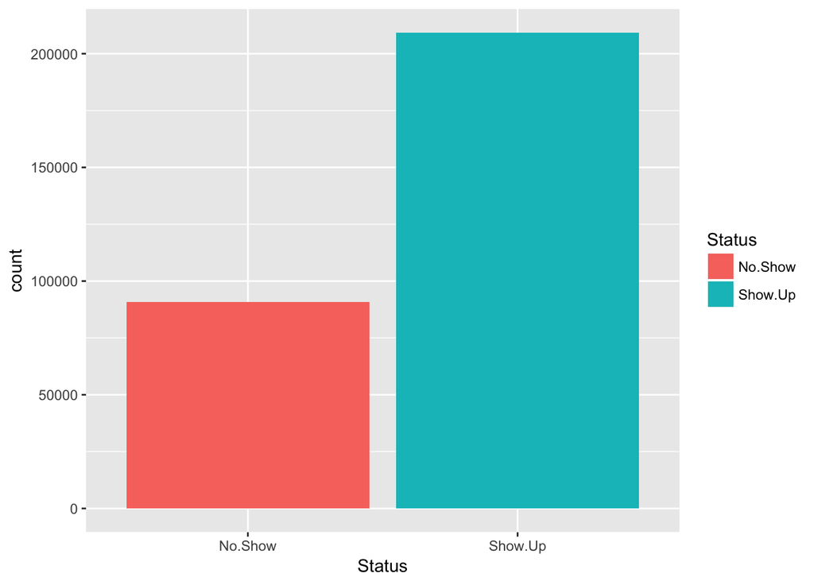

```
##
## No.Show Show.Up
##   90731  209269
```

Propotion of the patients that don’t show up is high. Seems that the dataset is not random.

### Sex and age

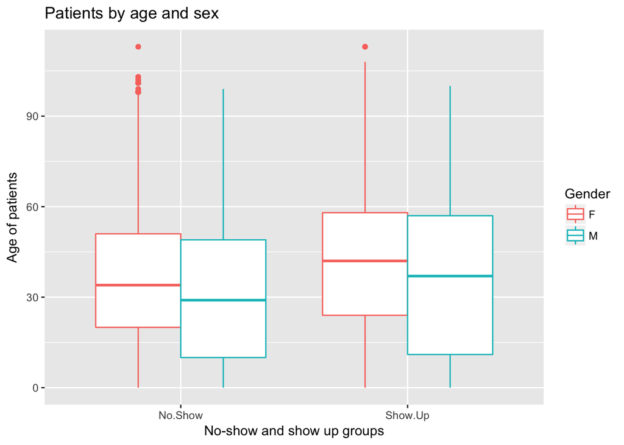

```r
#a boxplot of high_use, sex and age
g1 <- ggplot(noshow, aes(x = Status, y = Age, col = Gender))
g1 + geom_boxplot() + ggtitle("Patients by age and sex") + xlab("No-show and show up groups") + ylab("Age of patients")
```

## No-Shows in time

```
##
##             2014   2015    Sum
##   No.Show  46336  44395  90731
##   Show.Up 107668 101601 209269
##   Sum     154004 145996 300000
```

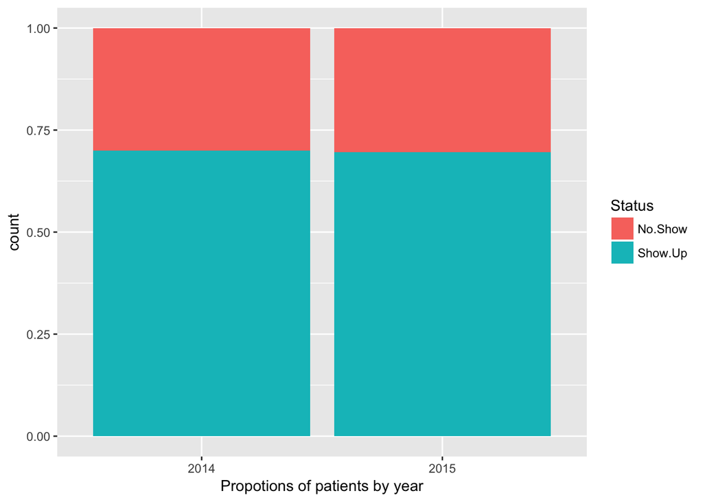

Propotion of the patient gropus seems to be identical between both years.

```
##
##                1      2      3      4      5      6      7      8      9
##   No.Show   6438   6713   7295   7440   7696   7866   8656   7551   7517
##   Show.Up  16393  15926  17375  16430  18367  17739  18799  18463  18323
##   Sum      22831  22639  24670  23870  26063  25605  27455  26014  25840
##
##               10     11     12    Sum
##   No.Show   8336   7640   7583  90731
##   Show.Up  18655  17728  15071 209269
##   Sum      26991  25368  22654 300000
```

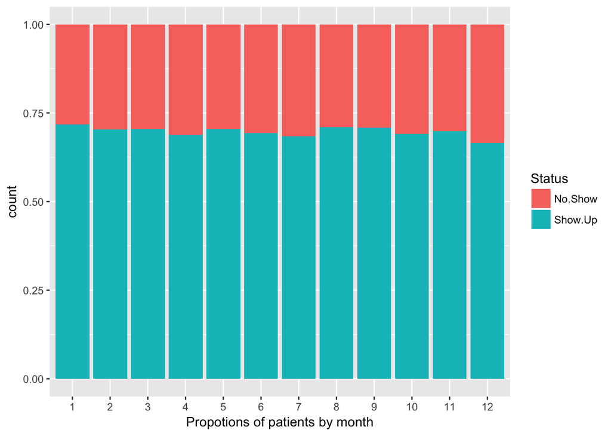

The propotion of patients who do not show up on appointment is steady during months. There seems to be slight trend that at end of the year no-shows are increasing but the effect seesm to be modest.

```
##
##           Monday Tuesday Wednesday Thursday Friday Saturday Sunday    Sum
##   No.Show  19053   18149     18919    17850  16246      513      1  90731
##   Show.Up  40245   44626     44576    42412  36525      880      5 209269
##   Sum      59298   62775     63495    60262  52771     1393      6 300000
```

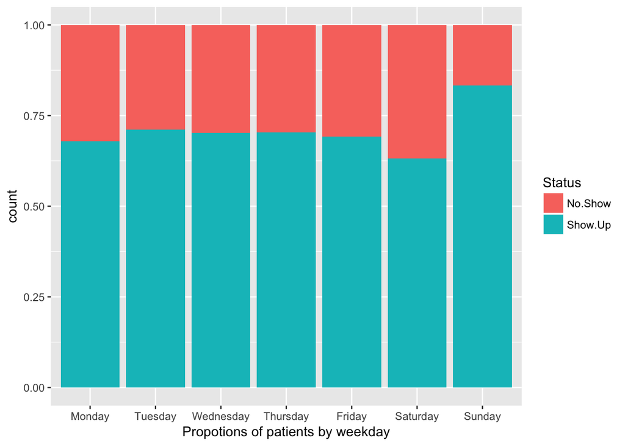

It seems that there is no significant difference in patient groups by weekday. At sundays there seems to be less no-shows but on the other hand there is only 6 patients in two years on sundays.

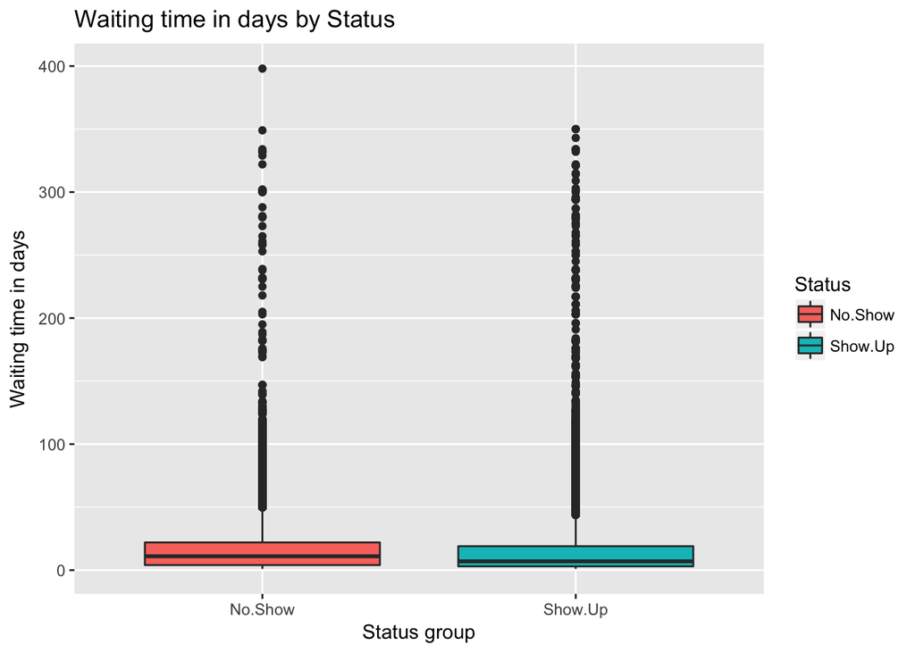

It seems that scale of the waiting time is so twisted that it makes the interpretation quite hard.

```
##    Min. 1st Qu.  Median    Mean 3rd Qu.    Max.
##    1.00    4.00    8.00   13.84   20.00  398.00
```

We need to divide the variable into intervals. Quantile points of the variable WaitingTimeDays are:

```
## WaitingTimeIntervals
##     short med_short  med_long      long
##     95507     59975     70674     73844
```

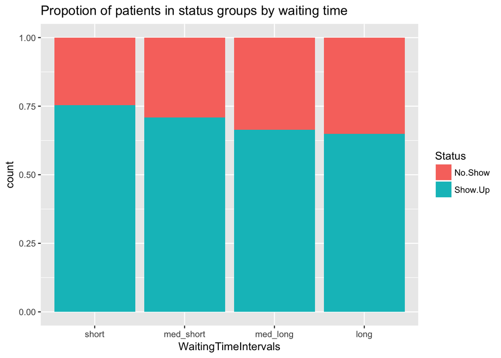

It seems that the propotion of the no-shows is getting higher when the waiting time is growing.

## Diseases and habits as binary variables

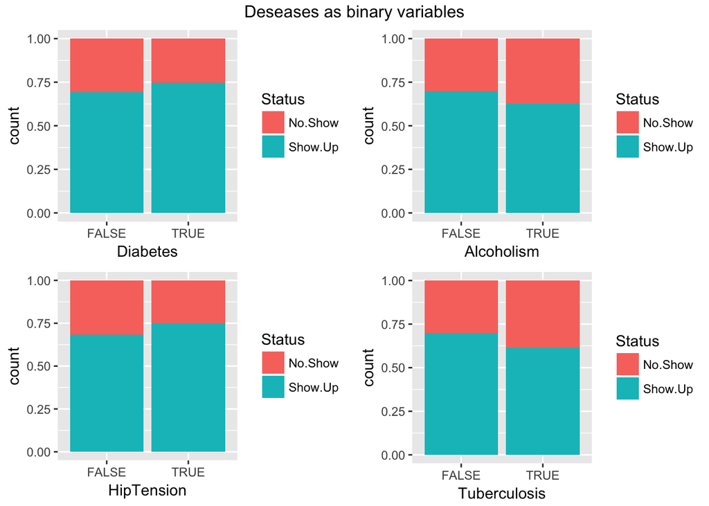

It seems that patients who has deseases like diabetes or hip tensions that require regular visit in hospital tend to be more prone to show up on appointment. Patients who suffer from alcoholism or tuberculosis do not visit hospital on regular basis and maybe therefore they are more prone to have no-shows.

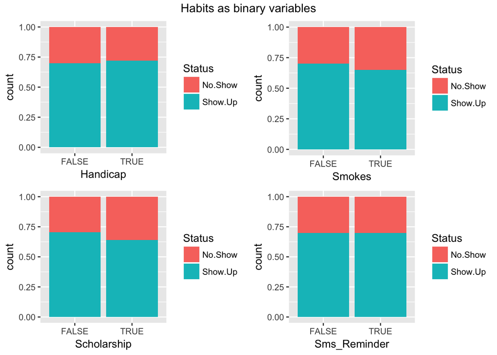

First glimpse to habits shows that the is no remarkable differences between no-show and show up patients. It suprising that even sms reminder do not make difference among patients at this data set.

# Part two: Logistic regression model

This is the second chapter of the final assignment. In this analysis we are using logistic regression model and trying predict patients who do not show up to appointment. In chapter one we reviewed differend variables against *Status* and find that others have greater variance than others.

## Explanatory variables

After careful consideration we use the following variables in logistic regression model

[output not shown]

```
##
## Call:
## glm(formula = Status ~ Age + WaitingTimeDays + Alcoholism + Diabetes +
##     Scholarship, family = "binomial", data = noshow)
##
## Deviance Residuals:
##     Min       1Q   Median       3Q      Max
## -1.9436  -1.4163   0.7682   0.8770   2.1846
##
## Coefficients:
##                   Estimate Std. Error z value Pr(>|z|)
## (Intercept)      0.6455852  0.0086056  75.019   <2e-16 ***
## Age              0.0096319  0.0001878  51.295   <2e-16 ***
## WaitingTimeDays -0.0092045  0.0002510 -36.665   <2e-16 ***
## AlcoholismTRUE  -0.4533036  0.0244384 -18.549   <2e-16 ***
## DiabetesTRUE     0.0079172  0.0164253   0.482     0.63
## ScholarshipTRUE -0.2163479  0.0130791 -16.541   <2e-16 ***
## ---
## Signif. codes:  0 '***' 0.001 '**' 0.01 '*' 0.05 '.' 0.1 ' ' 1
##
## (Dispersion parameter for binomial family taken to be 1)
##
##     Null deviance: 367749  on 299999  degrees of freedom
## Residual deviance: 362815  on 299994  degrees of freedom
## AIC: 362827
##
## Number of Fisher Scoring iterations: 4
```

## Odds ratio

```
##                        OR     2.5 %    97.5 %
## (Intercept)     1.9071028 1.8752198 1.9395568
## Age             1.0096784 1.0093070 1.0100502
## WaitingTimeDays 0.9908377 0.9903500 0.9913251
## AlcoholismTRUE  0.6355252 0.6058530 0.6667654
## DiabetesTRUE    1.0079487 0.9760722 1.0409861
## ScholarshipTRUE 0.8054550 0.7850882 0.8263892
```

Odds ratio (OR) and the 95% confidence interval (CI) shows that those patients who shuffer from alcoholism are almost 2/3 times more likely to not show on an appointment. Patients with a diabetes are excluded from the model because confidence interval shows that *diabetes* is not statistically significant (because the interval contains 1) and other variables are.

# Part three: Predictions

```
##
## Call:
## glm(formula = Status ~ Age + WaitingTimeDays + Alcoholism + Scholarship,
##     family = "binomial", data = noshow)
##
## Deviance Residuals:
##     Min       1Q   Median       3Q      Max
## -1.9447  -1.4163   0.7685   0.8770   2.1851
##
## Coefficients:
##                   Estimate Std. Error z value Pr(>|z|)
## (Intercept)      0.6452307  0.0085742   75.25   <2e-16 ***
## Age              0.0096585  0.0001795   53.81   <2e-16 ***
## WaitingTimeDays -0.0092075  0.0002510  -36.69   <2e-16 ***
## AlcoholismTRUE  -0.4533132  0.0244382  -18.55   <2e-16 ***
## ScholarshipTRUE -0.2163262  0.0130790  -16.54   <2e-16 ***
## ---
## Signif. codes:  0 '***' 0.001 '**' 0.01 '*' 0.05 '.' 0.1 ' ' 1
##
## (Dispersion parameter for binomial family taken to be 1)
##
##     Null deviance: 367749  on 299999  degrees of freedom
## Residual deviance: 362815  on 299995  degrees of freedom
## AIC: 362825
##
## Number of Fisher Scoring iterations: 4
```

```
## 'data.frame':    300000 obs. of  26 variables:
##  $ Age                    : int  19 24 4 5 38 5 46 4 20 51 ...
##  $ Gender                 : Factor w/ 2 levels "F","M": 2 1 1 2 2 1 1 1 1 1 ...
##  $ AppointmentRegistration: Date, format: "2014-12-16" "2015-08-18" ...
##  $ AppointmentData        : Date, format: "2015-01-14" "2015-08-19" ...
##  $ DayOfTheWeek           : Factor w/ 7 levels "Monday","Tuesday",..: 3 3 2 4 2 2 2 5 2 2 ...
##  $ Status                 : Factor w/ 2 levels "No.Show","Show.Up": 2 2 2 2 2 1 2 2 2 2 ...
##  $ Diabetes               : logi  FALSE FALSE FALSE FALSE FALSE FALSE ...
##  $ Alcoholism             : logi  FALSE FALSE FALSE FALSE FALSE FALSE ...
##  $ HipTension             : logi  FALSE FALSE FALSE FALSE FALSE FALSE ...
##  $ Handicap               : logi  FALSE FALSE FALSE FALSE FALSE FALSE ...
##  $ Smokes                 : logi  FALSE FALSE FALSE FALSE FALSE FALSE ...
##  $ Scholarship            : logi  FALSE FALSE FALSE FALSE FALSE FALSE ...
##  $ Tuberculosis           : logi  FALSE FALSE FALSE FALSE FALSE FALSE ...
##  $ Sms_Reminder           : logi  FALSE FALSE FALSE TRUE TRUE TRUE ...
##  $ WaitingTimeDays        : int  29 1 1 15 6 35 18 14 14 4 ...
##  $ RegYear                : Factor w/ 3 levels "2013","2014",..: 2 3 2 2 3 2 3 3 2 2 ...
##  $ RegMonth               : Factor w/ 12 levels "1","2","3","4",..: 12 8 2 7 10 6 6 8 10 6 ...
##  $ RegDay                 : Factor w/ 31 levels "1","2","3","4",..: 16 18 17 23 21 17 19 7 14 13 ...
##  $ RegWeekDay             : Factor w/ 7 levels "Keskiviikko",..: 6 6 3 1 1 6 4 4 6 4 ...
##  $ AppYear                : Factor w/ 2 levels "2014","2015": 2 2 1 1 2 1 2 2 1 1 ...
##  $ AppMonth               : Factor w/ 12 levels "1","2","3","4",..: 1 8 2 8 10 7 7 8 10 6 ...
##  $ AppDay                 : Factor w/ 31 levels "1","2","3","4",..: 14 19 18 7 27 22 7 21 28 17 ...
##  $ AppWeekDay             : Factor w/ 7 levels "Keskiviikko",..: 1 1 6 7 6 6 6 4 6 6 ...
##  $ WaitingTimeIntervals   : Factor w/ 4 levels "short","med_short",..: 4 1 1 3 2 4 3 3 3 1 ...
##  $ probability            : num  0.637 0.704 0.663 0.635 0.723 ...
##  $ prediction             : Named logi  TRUE TRUE TRUE TRUE TRUE TRUE ...
##   ..- attr(*, "names")= chr  "1" "2" "3" "4" ...
```

```
##          Prediction
## Status     FALSE   TRUE
##   No.Show    274  90457
##   Show.Up    382 208887
```